# Part 1: Intro to R/Tidyverse

Stephanie Hickey

2023-10-23

[Arjun Krishnan](https://thekrishnanlab.org) and [Janani Ravi](https://jravilab.github.io) co-developed the content for Part 1 of this workshop. See their repo [here](https://github.com/jananiravi/workshop-tidyverse/tree/main/transcriptomics).

# Section 1: Getting Started w/ `readr`

You can access all relevant material pertaining to this workshop [here](https://github.com/slepphickey/RNA-seq_RRM_2023). Other related workshops & useful cheatsheets.

*Trouble with local installation?* Login & start using [**RStudio Cloud**](https://rstudio.cloud) right away!

### Install packages

If you haven’t already

```r
install.packages("tidyverse")
```

If you’re having trouble installing the entire tidyverse, you can install these individual packages instead

```r
# If tidyverse installation fails, install individual constituent packages this way...
install.packages("readr")    # Importing data files
install.packages("tidyr")    # Tidy Data
install.packages("dplyr")    # Data manipulation
install.packages("ggplot2")  # Data Visualization (w/ Grammar of Graphics)
install.packages("readxl")   # Importing excel files
```

### Loading packages

```r
library(tidyverse)
```

```r
# OR load the individual packages, if you have trouble installing/loading `tidyverse`
# library(readr)
# library(readxl)
# library(tidyr)
# library(dplyr)
# library(ggplot2)
```

## Data import

There are various functions for reading and writing data in the tidyverse, including:

- `read_csv`, `write_csv`
- `read_tsv`, `write_tsv`
- `read_delim`, `write_delim`
- `read_excel`

Examples:

```r
# Comma-separated values, as exported from excel/spreadsheets
data = read_csv(file="path/to/my_data.csv", col_names=T)

# Other atypical delimiters
data = read_delim(file="path/to/my_data.txt", col_names=T, delim="//")

# Other useful packages
# readxl by Jenny Bryan
data = read_excel(path="path/to/excel.xls",
           sheet=1,
           range="A1:D50",
           col_names=T)
```

Read in `GSE69360_part1_RNAseq.counts.txt`

```r
# tells us which directory we're currently in
# if you opened Rstudio by clicking `RNA-seq_RRM_2023.Rproj`
# you should already be in the `RNA-seq_RRM_2023` directory
getwd()
```

```
## [1] "/Users/stephanielepp/Desktop/repos/workshops/RNA-seq_RRM_2023"
```

```r
# if not use `setwd()` to set the working directory to `RNA-seq_RRM_2023`
# setwd("path/to/RNA-seq_RRM_2023")

gse69360 = read_tsv("data/GSE69360_part1_RNAseq.counts.txt")
```

## Getting to know your data

*Dataset details*:

- AA: Agilent Adult; AF: Agilent Fetus
- BA: BioChain Adult; BF: BioChain Fetus
- OA: OriGene Adult
- Tissues: Colon, Heart, Kidney, Liver, Lung, Stomach

```r
str(gse69360)              # Structure of the dataframe
gse69360                   # Data is in a cleaned up 'tibble' format by default
head(gse69360)             # Shows the top few observations (rows) of your dataframe
glimpse(gse69360)          # Info-dense summary of the data
View(head(gse69360, 100))  # View data in a visual GUI-based spreadsheet-like format

colnames(gse69360)         # Column names
nrow(gse69360)             # No. of rows
ncol(gse69360)             # No. of columns

gse69360[1:5,7:10]         # Subsetting a dataframe

## saving the data file
write_tsv(gse69360[1:100,7:12], "data/gse_subset.txt")
```

# Section 2: Reshaping data w/ `tidyr`

```r
pivot_longer()  # Pivot data from wide to long
pivot_wider()   # Pivot data from long to wide

separate() # Separate 1 COLUMN -> many COLUMNS
unite()    # Unite several COLUMNS -> 1 COLUMN
```

## Long data is tidy data

- `pivot_longer`: *Each row represents key-value pairs. Wide -> Long*
- `pivot_wider`: *Spread key-value pairs across multiple columns: Long -> Wide*

```r
# pivot longer all columns except 'Geneid'

gse69360 %>% # Pipe ('then') operator serially connects operations
  select(Geneid, matches("[AF]_")) %>% # select only the Geneid and sample columns, then...
  pivot_longer(cols=matches("[AF]_"),  # columns we want to pivot longer into a new column
               names_to="Sample",      # name of the new column
               values_to="Counts")     # name of value column
```

```
## # A tibble: 1,098,580 × 3
##    Geneid            Sample     Counts
##    <chr>             <chr>       <dbl>
##  1 ENSG00000223972.4 AA_Colon        1
##  2 ENSG00000223972.4 AA_Heart        0
##  3 ENSG00000223972.4 AA_Kidney       0
##  4 ENSG00000223972.4 AA_Liver        0
##  5 ENSG00000223972.4 AA_Lung         0
##  6 ENSG00000223972.4 AA_Stomach      0
##  7 ENSG00000223972.4 AF_Colon        7
##  8 ENSG00000223972.4 AF_Stomach      2
##  9 ENSG00000223972.4 BA_Colon        0
## 10 ENSG00000223972.4 BA_Heart        0
## # ℹ 1,098,570 more rows
```

```r
# pivot longer, then wider --> Back to original data
gse69360 %>%
  select(Geneid, matches("[AF]_")) %>%
  pivot_longer(cols=matches("[AF]_"), names_to="Sample", values_to="Counts") %>% # wide -> long
  pivot_wider(names_from="Sample", values_from="Counts") # long -> wide
```

```
## # A tibble: 57,820 × 20
##    Geneid       AA_Colon AA_Heart AA_Kidney AA_Liver AA_Lung
##    <chr>           <dbl>    <dbl>     <dbl>    <dbl>   <dbl>
##  1 ENSG0000022…        1        0         0        0       0
##  2 ENSG0000022…       36       21        32       28      17
##  3 ENSG0000024…        0        0         0        0       0
##  4 ENSG0000023…        0        0         0        0       0
##  5 ENSG0000026…        0        0         0        0       0
##  6 ENSG0000024…        0        0         0        0       0
##  7 ENSG0000018…        0        0         0        0       0
##  8 ENSG0000023…        3        0         1        2       1
##  9 ENSG0000023…        0        0         0        0       0
## 10 ENSG0000023…        0        0         0        0       0
## # ℹ 57,810 more rows
## # ℹ 14 more variables: AA_Stomach <dbl>, AF_Colon <dbl>,
## #   AF_Stomach <dbl>, BA_Colon <dbl>, BA_Heart <dbl>,
## #   BA_Kidney <dbl>, BA_Liver <dbl>, BA_Lung <dbl>,
## #   BA_Stomach <dbl>, BF_Colon <dbl>, BF_Stomach <dbl>,
## #   OA_Stomach1 <dbl>, OA_Stomach2 <dbl>, OA_Stomach3 <dbl>
```

## Unite, Separate

- `separate`: *Separate one column into multiple columns*
- `unite`: *Unite multiple columns into one*

```r
# separate `Sample` column into `Source_Stage` and `Tissue` columns
gse69360 %>%
  select(Geneid, matches("[AF]_")) %>%               # selecting only Geneid and Counts columns
  pivot_longer(cols=matches("[AF]_"), names_to="Sample", values_to="Counts") %>% # wide -> long
  separate(Sample, into=c("Source_Stage", "Tissue"), sep="_") # separate by delimiter
```

```
## # A tibble: 1,098,580 × 4
##    Geneid            Source_Stage Tissue  Counts
##    <chr>             <chr>        <chr>    <dbl>
##  1 ENSG00000223972.4 AA           Colon        1
##  2 ENSG00000223972.4 AA           Heart        0
##  3 ENSG00000223972.4 AA           Kidney       0
##  4 ENSG00000223972.4 AA           Liver        0
##  5 ENSG00000223972.4 AA           Lung         0
##  6 ENSG00000223972.4 AA           Stomach      0
##  7 ENSG00000223972.4 AF           Colon        7
##  8 ENSG00000223972.4 AF           Stomach      2
##  9 ENSG00000223972.4 BA           Colon        0
## 10 ENSG00000223972.4 BA           Heart        0
## # ℹ 1,098,570 more rows
```

```r
# separate `Source_Stage` column into `Source` and `Stage` columns
gse69360 %>%
  select(Geneid, matches("[AF]_")) %>%
  pivot_longer(cols=matches("[AF]_"), names_to="Sample", values_to="Counts") %>%
  separate(Sample, into=c("Source_Stage", "Tissue"), sep="_") %>%
  separate(Source_Stage, into=c("Source", "Stage"), sep=1) # separate by char position
```

```
## # A tibble: 1,098,580 × 5
##    Geneid            Source Stage Tissue  Counts
##    <chr>             <chr>  <chr> <chr>    <dbl>
##  1 ENSG00000223972.4 A      A     Colon        1
##  2 ENSG00000223972.4 A      A     Heart        0
##  3 ENSG00000223972.4 A      A     Kidney       0
##  4 ENSG00000223972.4 A      A     Liver        0
##  5 ENSG00000223972.4 A      A     Lung         0
##  6 ENSG00000223972.4 A      A     Stomach      0
##  7 ENSG00000223972.4 A      F     Colon        7
##  8 ENSG00000223972.4 A      F     Stomach      2
##  9 ENSG00000223972.4 B      A     Colon        0
## 10 ENSG00000223972.4 B      A     Heart        0
## # ℹ 1,098,570 more rows
```

```r
# separate `Source_Stage` column into `Source` and `Stage` columns
gse69360[100,] %>%
  select(Geneid, matches("[AF]_")) %>%
  pivot_longer(cols=matches("[AF]_"), names_to="Sample", values_to="Counts") %>%
  separate(Sample, into=c("Source_Stage", "Tissue"), sep="_") %>%
  separate(Source_Stage, into=c("Source", "Stage"), sep=1) %>%
  unite(Stage_Tissue, Stage, Tissue) # combining a different set of columns
```

```
## # A tibble: 19 × 4
##    Geneid             Source Stage_Tissue Counts
##    <chr>              <chr>  <chr>         <dbl>
##  1 ENSG00000127054.14 A      A_Colon         430
##  2 ENSG00000127054.14 A      A_Heart         575
##  3 ENSG00000127054.14 A      A_Kidney        483
##  4 ENSG00000127054.14 A      A_Liver         714
##  5 ENSG00000127054.14 A      A_Lung          324
##  6 ENSG00000127054.14 A      A_Stomach       582
##  7 ENSG00000127054.14 A      F_Colon        1619
##  8 ENSG00000127054.14 A      F_Stomach       719
##  9 ENSG00000127054.14 B      A_Colon         195
## 10 ENSG00000127054.14 B      A_Heart         457
## 11 ENSG00000127054.14 B      A_Kidney        366
## 12 ENSG00000127054.14 B      A_Liver         244
## 13 ENSG00000127054.14 B      A_Lung          439
## 14 ENSG00000127054.14 B      A_Stomach       160
## 15 ENSG00000127054.14 B      F_Colon        1655
## 16 ENSG00000127054.14 B      F_Stomach      1632
## 17 ENSG00000127054.14 O      A_Stomach1      478
## 18 ENSG00000127054.14 O      A_Stomach2      688
## 19 ENSG00000127054.14 O      A_Stomach3      334
```

# Section 3: Data wranging with `dplyr`

```r
conflicted::conflict_prefer(name="filter", winner="dplyr")
filter()    # PICK observations by their values | ROWS
select()    # PICK variables by their names | COLUMNS
mutate()    # CREATE new variables w/ functions of existing variables | COLUMNS
transmute() # COMPUTE 1 or more COLUMNS but drop original columns
arrange()   # REORDER the ROWS
summarize() # COLLAPSE many values to a single SUMMARY
group_by()  # GROUP data into rows with the same value of variable (COLUMN)
```

## Filter

- `filter`: *Return rows with matching conditions*

```r
head(gse69360) # Snapshot of the dataframe
```

```
## # A tibble: 6 × 25
##   Geneid   Chr   Start End   Strand Length AA_Colon AA_Heart
##   <chr>    <chr> <chr> <chr> <chr>   <dbl>    <dbl>    <dbl>
## 1 ENSG000… chr1… 1186… 1222… +;+;+…   1756        1        0
## 2 ENSG000… chr1… 1436… 1482… -;-;-…   2073       36       21
## 3 ENSG000… chr1… 2955… 3003… +;+;+    1021        0        0
## 4 ENSG000… chr1… 3455… 3517… -;-;-    1219        0        0
## 5 ENSG000… chr1… 5247… 5331… +;+       947        0        0
## 6 ENSG000… chr1  62948 63887 +         940        0        0
## # ℹ 17 more variables: AA_Kidney <dbl>, AA_Liver <dbl>,
## #   AA_Lung <dbl>, AA_Stomach <dbl>, AF_Colon <dbl>,
## #   AF_Stomach <dbl>, BA_Colon <dbl>, BA_Heart <dbl>,
## #   BA_Kidney <dbl>, BA_Liver <dbl>, BA_Lung <dbl>,
## #   BA_Stomach <dbl>, BF_Colon <dbl>, BF_Stomach <dbl>,
## #   OA_Stomach1 <dbl>, OA_Stomach2 <dbl>, OA_Stomach3 <dbl>
```

```r
# Now, filter by condition
filter(gse69360, Length<=50)
```

```
## # A tibble: 124 × 25
##    Geneid  Chr   Start End   Strand Length AA_Colon AA_Heart
##    <chr>   <chr> <chr> <chr> <chr>   <dbl>    <dbl>    <dbl>
##  1 ENSG00… chr1… 3829… 3829… -;-        45        1        0
##  2 ENSG00… chr1  9521… 9521… -          41        7        1
##  3 ENSG00… chr1  1477… 1477… +          35        0        1
##  4 ENSG00… chr1… 1545… 1545… +;+        21        0        0
##  5 ENSG00… chr1  2360… 2360… -          50        1        2
##  6 ENSG00… chr2… 1160… 1160… +;+        36        1        0
##  7 ENSG00… chr2  8916… 8916… -          38      183        1
##  8 ENSG00… chr2  8916… 8916… -          37       98        2
##  9 ENSG00… chr2  8916… 8916… -          38       80        0
## 10 ENSG00… chr2  8916… 8916… -          38        0        0
## # ℹ 114 more rows
## # ℹ 17 more variables: AA_Kidney <dbl>, AA_Liver <dbl>,
## #   AA_Lung <dbl>, AA_Stomach <dbl>, AF_Colon <dbl>,
## #   AF_Stomach <dbl>, BA_Colon <dbl>, BA_Heart <dbl>,
## #   BA_Kidney <dbl>, BA_Liver <dbl>, BA_Lung <dbl>,
## #   BA_Stomach <dbl>, BF_Colon <dbl>, BF_Stomach <dbl>,
## #   OA_Stomach1 <dbl>, OA_Stomach2 <dbl>, …
```

```r
# Can be rewritten using "Piping" %>%
gse69360 %>%   # Pipe ('then') operator to serially connect operations
  filter(Length <= 50)
```

```
## # A tibble: 124 × 25
##    Geneid  Chr   Start End   Strand Length AA_Colon AA_Heart
##    <chr>   <chr> <chr> <chr> <chr>   <dbl>    <dbl>    <dbl>
##  1 ENSG00… chr1… 3829… 3829… -;-        45        1        0
##  2 ENSG00… chr1  9521… 9521… -          41        7        1
##  3 ENSG00… chr1  1477… 1477… +          35        0        1
##  4 ENSG00… chr1… 1545… 1545… +;+        21        0        0
##  5 ENSG00… chr1  2360… 2360… -          50        1        2
##  6 ENSG00… chr2… 1160… 1160… +;+        36        1        0
##  7 ENSG00… chr2  8916… 8916… -          38      183        1
##  8 ENSG00… chr2  8916… 8916… -          37       98        2
##  9 ENSG00… chr2  8916… 8916… -          38       80        0
## 10 ENSG00… chr2  8916… 8916… -          38        0        0
## # ℹ 114 more rows
## # ℹ 17 more variables: AA_Kidney <dbl>, AA_Liver <dbl>,
## #   AA_Lung <dbl>, AA_Stomach <dbl>, AF_Colon <dbl>,
## #   AF_Stomach <dbl>, BA_Colon <dbl>, BA_Heart <dbl>,
## #   BA_Kidney <dbl>, BA_Liver <dbl>, BA_Lung <dbl>,
## #   BA_Stomach <dbl>, BF_Colon <dbl>, BF_Stomach <dbl>,
## #   OA_Stomach1 <dbl>, OA_Stomach2 <dbl>, …
```

```r
# Filtering using regex/substring match
gse69360 %>%
  filter(grepl("chrY", Chr))
```

```
## # A tibble: 542 × 25
##    Geneid  Chr   Start End   Strand Length AA_Colon AA_Heart
##    <chr>   <chr> <chr> <chr> <chr>   <dbl>    <dbl>    <dbl>
##  1 ENSGR0… chrY… 1204… 1205… +;+       259        0        0
##  2 ENSGR0… chrY… 1429… 1430… +;+;+…   6191        0        0
##  3 ENSGR0… chrY… 1700… 1701… -;-;-…   2363        0        0
##  4 ENSGR0… chrY… 2317… 2319… +;+       428        0        0
##  5 ENSGR0… chrY… 2446… 2496… -;-;-…   9015        0        0
##  6 ENSGR0… chrY  3753… 3754… -         101        0        0
##  7 ENSGR0… chrY  4345… 4348… -         328        0        0
##  8 ENSGR0… chrY  4559… 4560… -         117        0        0
##  9 ENSGR0… chrY… 5350… 5353… +;+;+…   4384        0        0
## 10 ENSGR0… chrY… 9009… 9011… +;+       588        0        0
## # ℹ 532 more rows
## # ℹ 17 more variables: AA_Kidney <dbl>, AA_Liver <dbl>,
## #   AA_Lung <dbl>, AA_Stomach <dbl>, AF_Colon <dbl>,
## #   AF_Stomach <dbl>, BA_Colon <dbl>, BA_Heart <dbl>,
## #   BA_Kidney <dbl>, BA_Liver <dbl>, BA_Lung <dbl>,
## #   BA_Stomach <dbl>, BF_Colon <dbl>, BF_Stomach <dbl>,
## #   OA_Stomach1 <dbl>, OA_Stomach2 <dbl>, …
```

```r
# Two filters at a time
gse69360 %>%
  filter(Length <= 50 & grepl("chrY", Chr))
```

```
## # A tibble: 1 × 25
##   Geneid   Chr   Start End   Strand Length AA_Colon AA_Heart
##   <chr>    <chr> <chr> <chr> <chr>   <dbl>    <dbl>    <dbl>
## 1 ENSG000… chrY… 5306… 5306… -;-        42        1        0
## # ℹ 17 more variables: AA_Kidney <dbl>, AA_Liver <dbl>,
## #   AA_Lung <dbl>, AA_Stomach <dbl>, AF_Colon <dbl>,
## #   AF_Stomach <dbl>, BA_Colon <dbl>, BA_Heart <dbl>,
## #   BA_Kidney <dbl>, BA_Liver <dbl>, BA_Lung <dbl>,
## #   BA_Stomach <dbl>, BF_Colon <dbl>, BF_Stomach <dbl>,
## #   OA_Stomach1 <dbl>, OA_Stomach2 <dbl>, OA_Stomach3 <dbl>
```

```r
# Two filters at a time
gse69360 %>%
  filter(Length <= 50,
         grepl("chr10", Chr),
         Strand == "-;-")
```

```
## # A tibble: 0 × 25
## # ℹ 25 variables: Geneid <chr>, Chr <chr>, Start <chr>,
## #   End <chr>, Strand <chr>, Length <dbl>, AA_Colon <dbl>,
## #   AA_Heart <dbl>, AA_Kidney <dbl>, AA_Liver <dbl>,
## #   AA_Lung <dbl>, AA_Stomach <dbl>, AF_Colon <dbl>,
## #   AF_Stomach <dbl>, BA_Colon <dbl>, BA_Heart <dbl>,
## #   BA_Kidney <dbl>, BA_Liver <dbl>, BA_Lung <dbl>,
## #   BA_Stomach <dbl>, BF_Colon <dbl>, BF_Stomach <dbl>, …
```

## Select

- `select`: *Select/rename variables/columns by name*

```r
# Selecting columns that match a pattern
gse69360 %>%
  select(Geneid, matches(".F_"))
```

```
## # A tibble: 57,820 × 5
##    Geneid            AF_Colon AF_Stomach BF_Colon BF_Stomach
##    <chr>                <dbl>      <dbl>    <dbl>      <dbl>
##  1 ENSG00000223972.4        7          2        0          3
##  2 ENSG00000227232.4      102         41      153        157
##  3 ENSG00000243485.2        0          0        0          0
##  4 ENSG00000237613.2        0          0        0          0
##  5 ENSG00000268020.2        0          0        0          0
##  6 ENSG00000240361.1        0          0        0          0
##  7 ENSG00000186092.4        0          0        0          0
##  8 ENSG00000238009.2        4          0        5          4
##  9 ENSG00000239945.1        0          0        0          0
## 10 ENSG00000233750.3        2          3        3          1
## # ℹ 57,810 more rows
```

```r
# Excluding specific columns
gse69360 %>%
  select(-Chr, -Start, -End, -Strand, -Length)
```

```
## # A tibble: 57,820 × 20
##    Geneid       AA_Colon AA_Heart AA_Kidney AA_Liver AA_Lung
##    <chr>           <dbl>    <dbl>     <dbl>    <dbl>   <dbl>
##  1 ENSG0000022…        1        0         0        0       0
##  2 ENSG0000022…       36       21        32       28      17
##  3 ENSG0000024…        0        0         0        0       0
##  4 ENSG0000023…        0        0         0        0       0
##  5 ENSG0000026…        0        0         0        0       0
##  6 ENSG0000024…        0        0         0        0       0
##  7 ENSG0000018…        0        0         0        0       0
##  8 ENSG0000023…        3        0         1        2       1
##  9 ENSG0000023…        0        0         0        0       0
## 10 ENSG0000023…        0        0         0        0       0
## # ℹ 57,810 more rows
## # ℹ 14 more variables: AA_Stomach <dbl>, AF_Colon <dbl>,
## #   AF_Stomach <dbl>, BA_Colon <dbl>, BA_Heart <dbl>,
## #   BA_Kidney <dbl>, BA_Liver <dbl>, BA_Lung <dbl>,
## #   BA_Stomach <dbl>, BF_Colon <dbl>, BF_Stomach <dbl>,
## #   OA_Stomach1 <dbl>, OA_Stomach2 <dbl>, OA_Stomach3 <dbl>
```

```r
# Excluding columns matching a pattern
gse69360 %>%
  select(-matches("[AF]_"))
```

```
## # A tibble: 57,820 × 6
##    Geneid            Chr           Start End   Strand Length
##    <chr>             <chr>         <chr> <chr> <chr>   <dbl>
##  1 ENSG00000223972.4 chr1;chr1;ch… 1186… 1222… +;+;+…   1756
##  2 ENSG00000227232.4 chr1;chr1;ch… 1436… 1482… -;-;-…   2073
##  3 ENSG00000243485.2 chr1;chr1;ch… 2955… 3003… +;+;+    1021
##  4 ENSG00000237613.2 chr1;chr1;ch… 3455… 3517… -;-;-    1219
##  5 ENSG00000268020.2 chr1;chr1     5247… 5331… +;+       947
##  6 ENSG00000240361.1 chr1          62948 63887 +         940
##  7 ENSG00000186092.4 chr1          69091 70008 +         918
##  8 ENSG00000238009.2 chr1;chr1;ch… 8929… 9162… -;-;-…   3569
##  9 ENSG00000239945.1 chr1;chr1     8955… 9005… -;-      1319
## 10 ENSG00000233750.3 chr1          1310… 1348… +        3812
## # ℹ 57,810 more rows
```

```r
# Select then Filter
gse69360 %>%
  select(Geneid, Chr, Length, matches("[AF]_")) %>%
  filter(grepl("chrY", Chr) | Length <= 100)
```

```
## # A tibble: 4,671 × 22
##    Geneid  Chr   Length AA_Colon AA_Heart AA_Kidney AA_Liver
##    <chr>   <chr>  <dbl>    <dbl>    <dbl>     <dbl>    <dbl>
##  1 ENSG00… chr1…     90        0        0         0        0
##  2 ENSG00… chr1…     57        0        0         0        0
##  3 ENSG00… chr1      95        5        0         2        0
##  4 ENSG00… chr1      90        0        0         0        0
##  5 ENSG00… chr1      83        7        0         1        2
##  6 ENSG00… chr1      96        0        0         0        0
##  7 ENSG00… chr1      70        0        0         0        0
##  8 ENSG00… chr1      73        0        0         0        0
##  9 ENSG00… chr1      89        0        0         0        0
## 10 ENSG00… chr1      70        0        0         0        0
## # ℹ 4,661 more rows
## # ℹ 15 more variables: AA_Lung <dbl>, AA_Stomach <dbl>,
## #   AF_Colon <dbl>, AF_Stomach <dbl>, BA_Colon <dbl>,
## #   BA_Heart <dbl>, BA_Kidney <dbl>, BA_Liver <dbl>,
## #   BA_Lung <dbl>, BA_Stomach <dbl>, BF_Colon <dbl>,
## #   BF_Stomach <dbl>, OA_Stomach1 <dbl>, OA_Stomach2 <dbl>,
## #   OA_Stomach3 <dbl>
```

## Mutate

- `mutate`: *Adds new variables; keeps existing variables*
- `transmute`: *Adds new variables; drops existing variables*

**Helpful resources** - Regular expressions [quickstart](https://www.regular-expressions.info/quickstart.html) - Regular expression [tester](https://regex101.com/)

```r
# Storing gene location information in a separate dataframe
gene_loc <- gse69360 %>%                                            # saving output to a variable
  select(-matches("[AF]_")) %>%                                     # select columns
  mutate(Geneid = gsub("\\.[0-9]*$", "", Geneid)) %>%               # remove isoform no.
  mutate(Chr = gsub(";.*", "", Chr)) %>%                            # keep the first element for Chr
  mutate(Start = as.numeric(gsub(";.*", "", Start))) %>%            # "" for Start
  mutate(End = as.numeric(gsub(";.*", "", End))) %>%                # "" for End
  mutate(Strand = gsub(";.*", "",Strand))                           # "" for Strand

# Check to see if you have what you expected!
gene_loc
```

```
## # A tibble: 57,820 × 6
##    Geneid          Chr    Start    End Strand Length
##    <chr>           <chr>  <dbl>  <dbl> <chr>   <dbl>
##  1 ENSG00000223972 chr1   11869  12227 +        1756
##  2 ENSG00000227232 chr1   14363  14829 -        2073
##  3 ENSG00000243485 chr1   29554  30039 +        1021
##  4 ENSG00000237613 chr1   34554  35174 -        1219
##  5 ENSG00000268020 chr1   52473  53312 +         947
##  6 ENSG00000240361 chr1   62948  63887 +         940
##  7 ENSG00000186092 chr1   69091  70008 +         918
##  8 ENSG00000238009 chr1   89295  91629 -        3569
##  9 ENSG00000239945 chr1   89551  90050 -        1319
## 10 ENSG00000233750 chr1  131025 134836 +        3812
## # ℹ 57,810 more rows
```

```r
head(gene_loc, 10)
```

```
## # A tibble: 10 × 6
##    Geneid          Chr    Start    End Strand Length
##    <chr>           <chr>  <dbl>  <dbl> <chr>   <dbl>
##  1 ENSG00000223972 chr1   11869  12227 +        1756
##  2 ENSG00000227232 chr1   14363  14829 -        2073
##  3 ENSG00000243485 chr1   29554  30039 +        1021
##  4 ENSG00000237613 chr1   34554  35174 -        1219
##  5 ENSG00000268020 chr1   52473  53312 +         947
##  6 ENSG00000240361 chr1   62948  63887 +         940
##  7 ENSG00000186092 chr1   69091  70008 +         918
##  8 ENSG00000238009 chr1   89295  91629 -        3569
##  9 ENSG00000239945 chr1   89551  90050 -        1319
## 10 ENSG00000233750 chr1  131025 134836 +        3812
```

```r
# Creating new variables
gene_loc %>%
  mutate(kbStart = Start/1000,     # creates new variables/columns
         kbEnd = End/1000,
         kbLength = Length/1000)
```

```
## # A tibble: 57,820 × 9
##    Geneid    Chr    Start    End Strand Length kbStart kbEnd
##    <chr>     <chr>  <dbl>  <dbl> <chr>   <dbl>   <dbl> <dbl>
##  1 ENSG0000… chr1   11869  12227 +        1756    11.9  12.2
##  2 ENSG0000… chr1   14363  14829 -        2073    14.4  14.8
##  3 ENSG0000… chr1   29554  30039 +        1021    29.6  30.0
##  4 ENSG0000… chr1   34554  35174 -        1219    34.6  35.2
##  5 ENSG0000… chr1   52473  53312 +         947    52.5  53.3
##  6 ENSG0000… chr1   62948  63887 +         940    62.9  63.9
##  7 ENSG0000… chr1   69091  70008 +         918    69.1  70.0
##  8 ENSG0000… chr1   89295  91629 -        3569    89.3  91.6
##  9 ENSG0000… chr1   89551  90050 -        1319    89.6  90.0
## 10 ENSG0000… chr1  131025 134836 +        3812   131.  135.
## # ℹ 57,810 more rows
## # ℹ 1 more variable: kbLength <dbl>
```

```r
# Creating new variables & dropping old ones
gene_loc %>%
  transmute(kbStart = Start/1000,  # drops original columns
            kbEnd = End/1000,
            kbLength = Length/1000)
```

```
## # A tibble: 57,820 × 3
##    kbStart kbEnd kbLength
##      <dbl> <dbl>    <dbl>
##  1    11.9  12.2    1.76
##  2    14.4  14.8    2.07
##  3    29.6  30.0    1.02
##  4    34.6  35.2    1.22
##  5    52.5  53.3    0.947
##  6    62.9  63.9    0.94
##  7    69.1  70.0    0.918
##  8    89.3  91.6    3.57
##  9    89.6  90.0    1.32
## 10   131.  135.     3.81
## # ℹ 57,810 more rows
```

## Distinct & Arrange

- `distinct`: *Pick unique entries*
- `arrange`: *Arrange rows by variables*

```r
# Pick only the unique entries in a column
gene_loc %>%
  distinct(Chr)
```

```
## # A tibble: 25 × 1
##    Chr
##    <chr>
##  1 chr1
##  2 chr2
##  3 chr3
##  4 chr4
##  5 chr5
##  6 chr6
##  7 chr7
##  8 chr8
##  9 chr9
## 10 chr10
## # ℹ 15 more rows
```

```r
gene_loc %>%
  distinct(Strand)
```

```
## # A tibble: 2 × 1
##   Strand
##   <chr>
## 1 +
## 2 -
```

```r
# Pick unique combinations
gene_loc %>%
  distinct(Chr, Strand)
```

```
## # A tibble: 50 × 2
##    Chr   Strand
##    <chr> <chr>
##  1 chr1  +
##  2 chr1  -
##  3 chr2  -
##  4 chr2  +
##  5 chr3  +
##  6 chr3  -
##  7 chr4  -
##  8 chr4  +
##  9 chr5  +
## 10 chr5  -
## # ℹ 40 more rows
```

```r
# Then sort aka arrange your data
gene_loc %>%
  arrange(desc(Chr))    # sort in descending order
```

```
## # A tibble: 57,820 × 6
##    Geneid          Chr    Start    End Strand Length
##    <chr>           <chr>  <dbl>  <dbl> <chr>   <dbl>
##  1 ENSGR0000228572 chrY  120410 120513 +         259
##  2 ENSGR0000182378 chrY  142989 143061 +        6191
##  3 ENSGR0000178605 chrY  170025 170137 -        2363
##  4 ENSGR0000226179 chrY  231725 231983 +         428
##  5 ENSGR0000167393 chrY  244698 249631 -        9015
##  6 ENSGR0000266731 chrY  375316 375416 -         101
##  7 ENSGR0000234958 chrY  434510 434837 -         328
##  8 ENSGR0000229232 chrY  455971 456087 -         117
##  9 ENSGR0000185960 chrY  535079 535337 +        4384
## 10 ENSGR0000237531 chrY  900956 901162 +         588
## # ℹ 57,810 more rows
```

```r
gene_loc %>%
  arrange(Chr, Length)  # sort by Chr, then Length
```

```
## # A tibble: 57,820 × 6
##    Geneid          Chr       Start       End Strand Length
##    <chr>           <chr>     <dbl>     <dbl> <chr>   <dbl>
##  1 ENSG00000268141 chr1  154585067 154585080 +          21
##  2 ENSG00000224335 chr1  147706573 147706607 +          35
##  3 ENSG00000263526 chr1   95211416  95211456 -          41
##  4 ENSG00000230610 chr1   38292232  38292262 -          45
##  5 ENSG00000252056 chr1  236026688 236026737 -          50
##  6 ENSG00000238705 chr1   26881033  26881084 +          52
##  7 ENSG00000264650 chr1   45499641  45499692 -          52
##  8 ENSG00000265769 chr1   52366592  52366643 -          52
##  9 ENSG00000251795 chr1   93303575  93303627 +          53
## 10 ENSG00000238310 chr1  109750416 109750470 -          55
## # ℹ 57,810 more rows
```

```r
# arrange(Chr, -Length) # to reverse sort by 'numeric' Length
```

## Group_by & Summarize

- `summarize`: *Reduces multiple values down to a single value*
- `group_by`: *Combine entries by one or more variables*

```r
# Combine by a variable, then calculate summary statistics for each group
gene_loc %>%
  group_by(Chr) %>%                         # group rows by Chr
  summarize(numGenes = n(),                 # then summarise, number of genes/Chr
            startoffirstGene = min(Start))  # min to get the first Start location
```

```
## # A tibble: 25 × 3
##    Chr   numGenes startoffirstGene
##    <chr>    <int>            <dbl>
##  1 chr1      5363            11869
##  2 chr10     2260            90652
##  3 chr11     3208            75780
##  4 chr12     2818            67607
##  5 chr13     1217         19041312
##  6 chr14     2244         19110203
##  7 chr15     2080         20083769
##  8 chr16     2343            61553
##  9 chr17     2903             4961
## 10 chr18     1127            11103
## # ℹ 15 more rows
```

```r
# Example to show you can use all math/stat functions to summarize data groups
gene_loc %>%
  arrange(Length) %>%
  group_by(Chr, Strand) %>%
  summarize(numGenes = n(),
            smallestGene = dplyr::first(Geneid),
            minLength = min(Length),
            firstqLength = quantile(Length, 0.25),
            medianLength = median(Length),
            iqrLength = IQR(Length),
            thirdqLength = quantile(Length, 0.75),
            maxLength = max(Length),
            longestGene = dplyr::last(Geneid))
```

```
## # A tibble: 50 × 11
## # Groups:   Chr [25]
##    Chr   Strand numGenes smallestGene minLength firstqLength
##    <chr> <chr>     <int> <chr>            <dbl>        <dbl>
##  1 chr1  +          2712 ENSG0000026…        21         394.
##  2 chr1  -          2651 ENSG0000026…        41         354.
##  3 chr10 +          1151 ENSG0000027…        27         356
##  4 chr10 -          1109 ENSG0000026…        52         322
##  5 chr11 +          1603 ENSG0000025…        37         476
##  6 chr11 -          1605 ENSG0000026…        30         477
##  7 chr12 +          1403 ENSG0000026…        30         402
##  8 chr12 -          1415 ENSG0000025…        28         375
##  9 chr13 +           586 ENSG0000026…        57         371.
## 10 chr13 -           631 ENSG0000021…        48         297
## # ℹ 40 more rows
## # ℹ 5 more variables: medianLength <dbl>, iqrLength <dbl>,
## #   thirdqLength <dbl>, maxLength <dbl>, longestGene <chr>
```

```r
# Saving your data locally
gene_loc %>%
  write_tsv("data/GSE69360.gene-locations.txt")
```

### More data wrangling

Let’s combine everything from above to tidy the full GSE69360 dataset.

Dataset details:

- AA: Agilent Adult; AF: Agilent Fetus
- BA: BioChain Adult; BF: BioChain Fetus
- OA: OriGene Adult
- Tissues: Colon, Heart, Kidney, Liver, Lung, Stomach

```r
# Extracting just the expression values & cleaning it up
View(head(gse69360, 50))

gene_counts <- gse69360 %>%
  select(-Chr, -Start, -End, -Strand, -Length) %>%          # another way to select just the expression data
  dplyr::rename(OA_Stomach = OA_Stomach1) %>%                      # rename couple of columns
  mutate(OA_Stomach2 = NULL, OA_Stomach3 = NULL) %>%        # remove a couple of columns
  mutate(Geneid = gsub("\\.[0-9]*$", "", Geneid))           # remove numbers after a period in the gene name

logcpm <- gene_counts %>%
  mutate(across(matches("[AF]_"), function(x) { log2((x*(1e+6)/sum(x)) + 1) }))  # convert counts in each sample to counts-per-million

summary(logcpm)
```

```
##     Geneid             AA_Colon           AA_Heart
##  Length:57820       Min.   : 0.00000   Min.   : 0.0000
##  Class :character   1st Qu.: 0.00000   1st Qu.: 0.0000
##  Mode  :character   Median : 0.06883   Median : 0.0000
##                     Mean   : 1.10187   Mean   : 0.8103
##                     3rd Qu.: 1.33045   3rd Qu.: 0.5151
##                     Max.   :18.41311   Max.   :18.7478
##    AA_Kidney          AA_Liver           AA_Lung
##  Min.   : 0.0000   Min.   : 0.00000   Min.   : 0.000
##  1st Qu.: 0.0000   1st Qu.: 0.00000   1st Qu.: 0.000
##  Median : 0.0000   Median : 0.05563   Median : 0.000
##  Mean   : 0.8785   Mean   : 0.98788   Mean   : 1.049
##  3rd Qu.: 0.7181   3rd Qu.: 0.95867   3rd Qu.: 1.123
##  Max.   :18.8061   Max.   :17.85244   Max.   :17.722
##    AA_Stomach          AF_Colon         AF_Stomach
##  Min.   : 0.00000   Min.   : 0.0000   Min.   : 0.0000
##  1st Qu.: 0.00000   1st Qu.: 0.0000   1st Qu.: 0.0000
##  Median : 0.06964   Median : 0.1995   Median : 0.0000
##  Mean   : 0.93120   Mean   : 1.2903   Mean   : 0.7748
##  3rd Qu.: 0.91851   3rd Qu.: 1.8951   3rd Qu.: 0.8105
##  Max.   :17.85986   Max.   :17.4620   Max.   :18.3586
##     BA_Colon           BA_Heart          BA_Kidney
##  Min.   : 0.00000   Min.   : 0.00000   Min.   : 0.00000
##  1st Qu.: 0.00000   1st Qu.: 0.00000   1st Qu.: 0.00000
##  Median : 0.08114   Median : 0.04537   Median : 0.05856
##  Mean   : 0.98586   Mean   : 0.80833   Mean   : 0.96659
##  3rd Qu.: 1.10906   3rd Qu.: 0.68444   3rd Qu.: 1.11092
##  Max.   :18.75742   Max.   :18.92846   Max.   :18.87617
##     BA_Liver          BA_Lung          BA_Stomach
##  Min.   : 0.0000   Min.   : 0.0000   Min.   : 0.0000
##  1st Qu.: 0.0000   1st Qu.: 0.1643   1st Qu.: 0.0000
##  Median : 0.0000   Median : 0.4456   Median : 0.0000
##  Mean   : 0.8194   Mean   : 1.3873   Mean   : 0.7528
##  3rd Qu.: 0.5974   3rd Qu.: 1.9392   3rd Qu.: 0.6261
##  Max.   :17.7612   Max.   :17.5495   Max.   :18.3249
##     BF_Colon         BF_Stomach        OA_Stomach
##  Min.   : 0.0000   Min.   : 0.0000   Min.   : 0.0000
##  1st Qu.: 0.0000   1st Qu.: 0.0000   1st Qu.: 0.0000
##  Median : 0.1793   Median : 0.3085   Median : 0.1003
##  Mean   : 1.3716   Mean   : 1.5164   Mean   : 1.0800
##  3rd Qu.: 1.9775   3rd Qu.: 2.4221   3rd Qu.: 1.3692
##  Max.   :15.8531   Max.   :15.7256   Max.   :17.9600
```

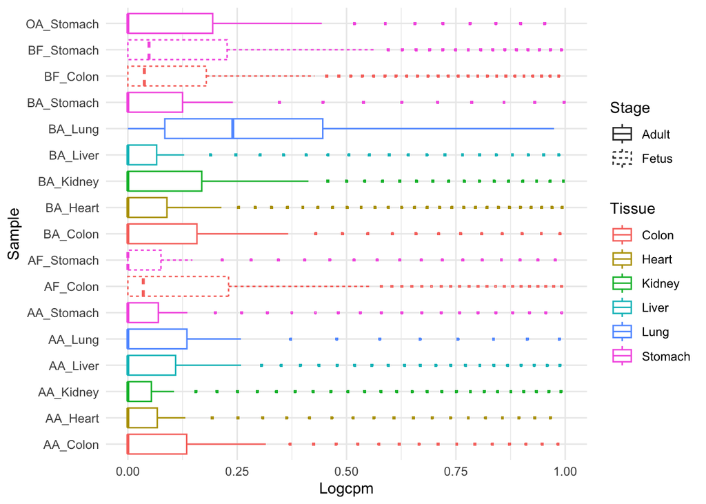

```r
log_cpm_long <-
  logcpm %>%
  pivot_longer(-Geneid, names_to="Sample", values_to="Logcpm") %>%     # convert to tidy data
  separate(Sample,                                                     # cleanup complex variables
           into = c("Source", "Stage", "Tissue"),
           sep = c(1,2),
           remove = F) %>%                                             # keep original variable
  mutate(Tissue = gsub("^_", "", Tissue),
         Stage = ifelse(Stage == "A", "Adult", "Fetus"),
         Source = case_when(                                           # another way to replace values
           Source == "A" ~ "Agilent",
           Source == "B" ~ "BioChain",
           Source == "O" ~ "OriGene"
         ))

View(head(log_cpm_long, 50))

# Plotting the distribution of gene-expression in each sample
log_cpm_long %>%
  ggplot(aes(x = Sample, y = Logcpm, color = Tissue, linetype = Stage)) +
    geom_boxplot(outlier.size = 0.2, outlier.shape = 0.2) +
    scale_y_continuous(limits = c(0, 1)) +
    coord_flip() +
    theme_minimal()
```

# Section 4: Visualizing tidy data w/ `ggplot`

## Basics of ggplot2

**Creating a plot w/ Grammar of Graphics**

> 1. Recap and continuation of **dplyr**
> 2. Basics of plotting data with **ggplot2**: `data`, `aes`, `geom`
> 3. Customization: Colors, labels, and legends

### Barplots & Histograms

- `ggplot`, `factor`, `aes`
- `geom_bar`, `geom_histogram`
- `facet_wrap`
- `scale_x_log10`, `labs`, `coord_flip`, `theme`, `theme_minimal`

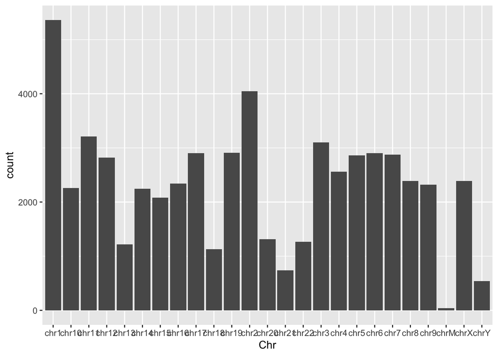

```r
gene_loc %>%                                                      # data
  ggplot(aes(x = Chr)) +                                          # aesthetics: what to plot?
    geom_bar()                                                    # geometry: how to plot?
```

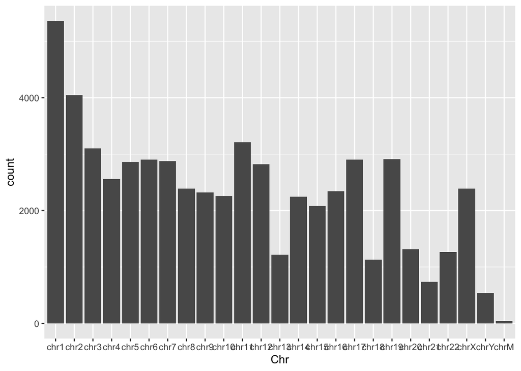

```r
# put chromosomes in specific order
gene_loc$Chr <- factor(gene_loc$Chr,
                       levels = paste("chr",
                                      c((1:22), "X", "Y", "M"),
                                      sep=""))

plot_chr_numgenes <-
  gene_loc %>%
    ggplot(aes(x = Chr)) +
      geom_bar()

plot_chr_numgenes
```

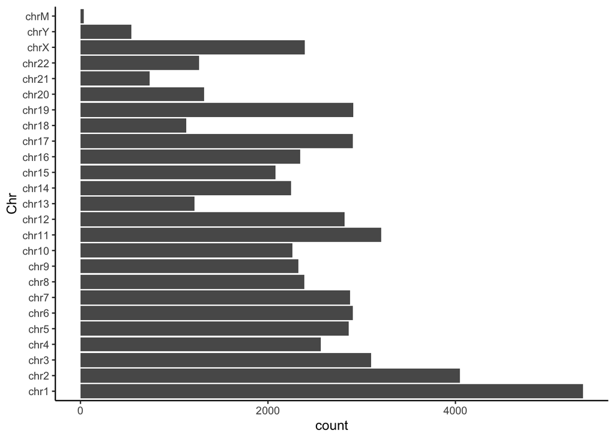

```r
plot_chr_numgenes +
  coord_flip() +
  theme_classic()
```

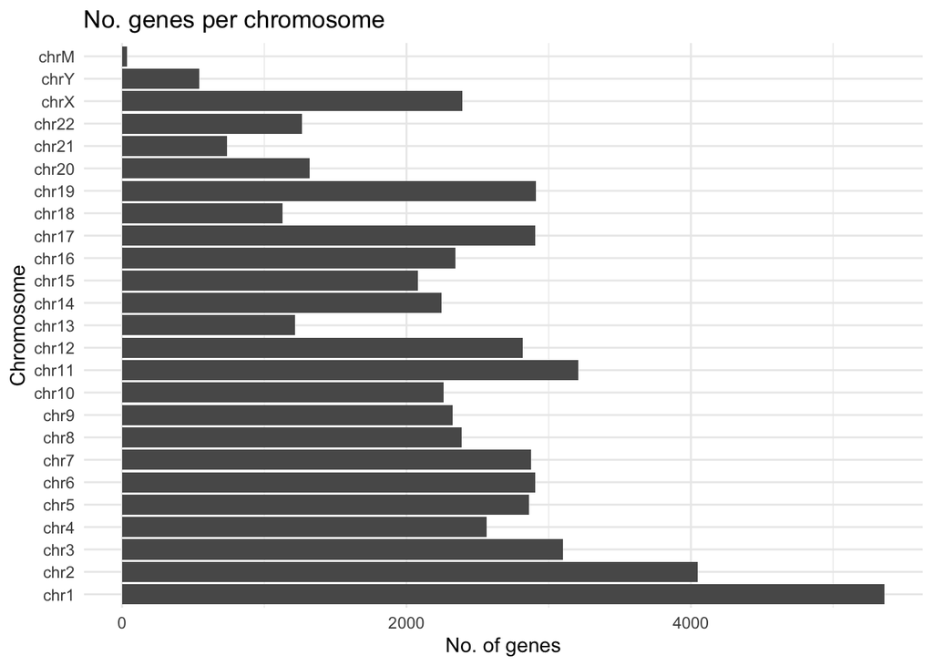

```r
plot_chr_numgenes +
  labs(title = "No. genes per chromosome",
       x = "Chromosome",
       y = "No. of genes") +
  theme_minimal() +
  coord_flip()
```

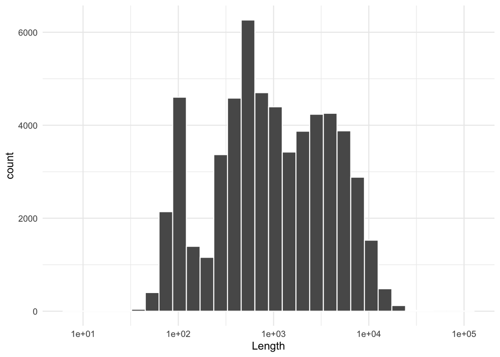

```r
gene_loc %>%
  ggplot(aes(x = Length)) +
    geom_histogram(color = "white") +
    scale_x_log10() +
    theme_minimal()
```

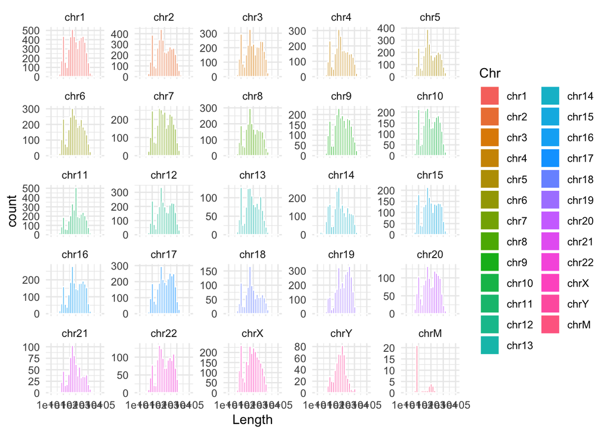

```r
plot_chr_genelength <- gene_loc %>%
  ggplot(aes(x = Length, fill = Chr)) +
    geom_histogram(color = "white") +
    scale_x_log10() +
    theme_minimal() +
    facet_wrap(~Chr, scales = "free_y")

plot_chr_genelength
```

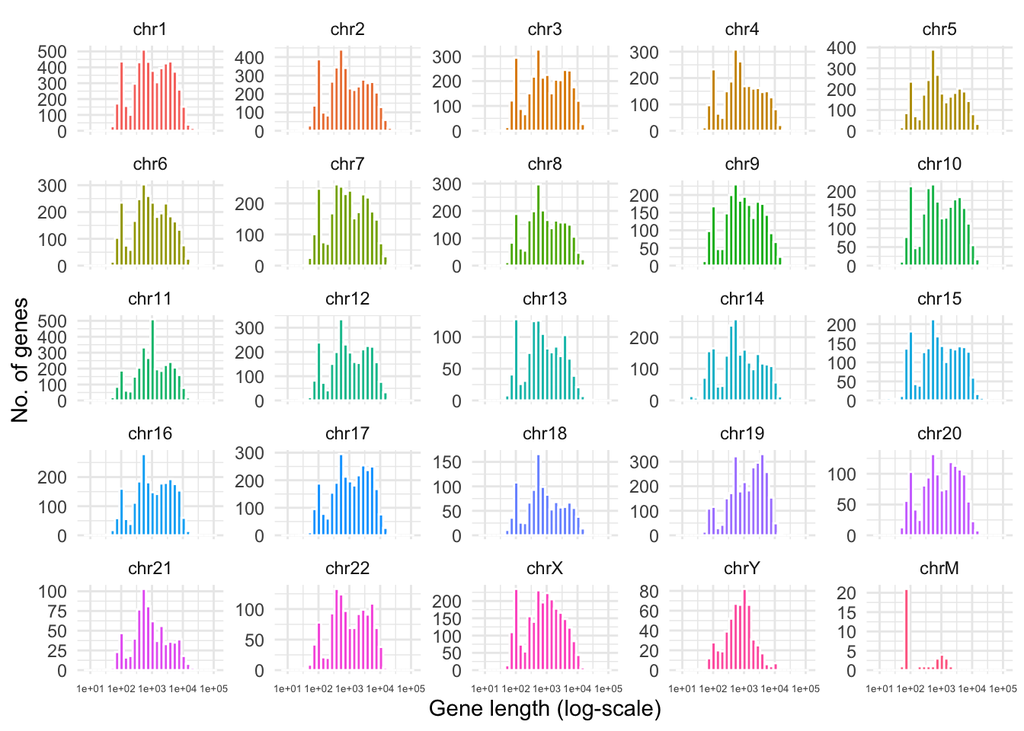

```r
plot_chr_genelength +
  theme(legend.position = "none",
        axis.text.x=element_text(size=5)) +
  labs(x = "Gene length (log-scale)",
       y = "No. of genes")
```

### Scatter plots

- `geom_point`
- `geom_abline`, `geom_vline`, `geom_hline`
- `geom_smooth`, `geom_text_repel`

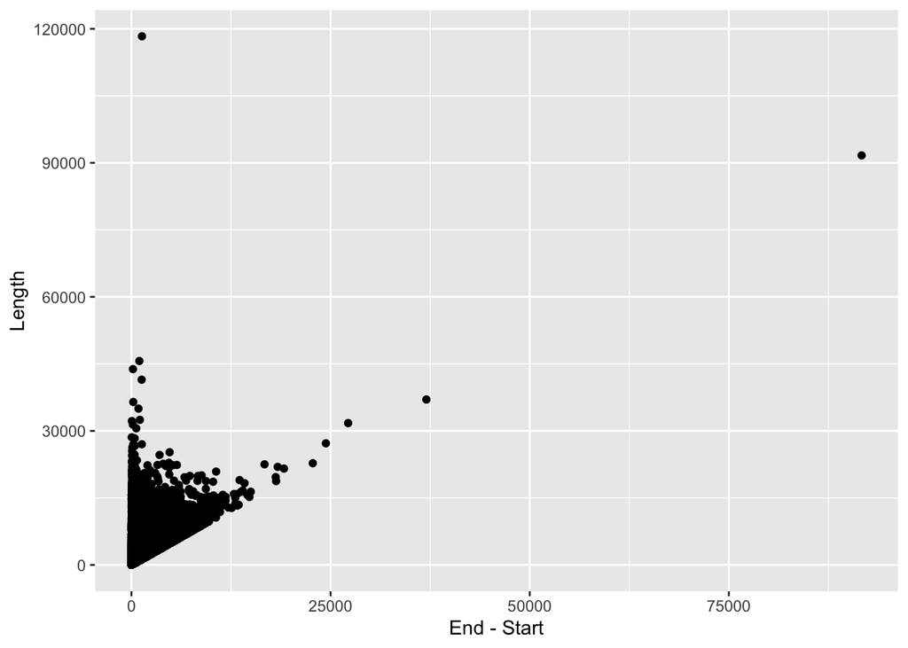

```r
gene_loc %>%
  ggplot(aes(x = End-Start, y = Length)) +
  geom_point()
```

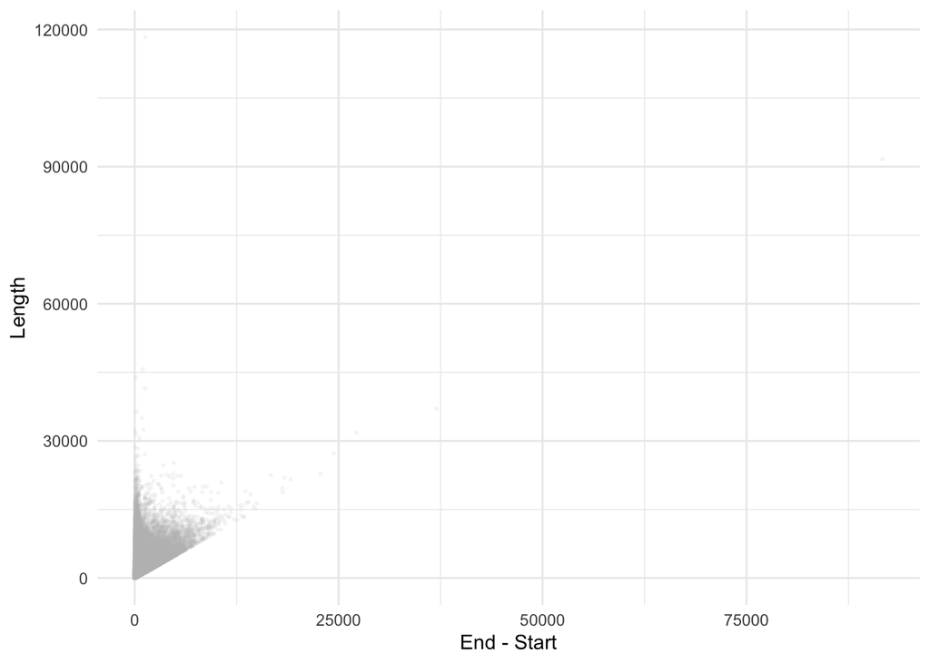

```r
plot_strend_length <-
  gene_loc %>%
    ggplot(aes(x = End-Start, y = Length)) +
      geom_point(alpha = 0.1, size = 0.5, color = "grey", fill = "grey") +
      theme_minimal()

plot_strend_length
```

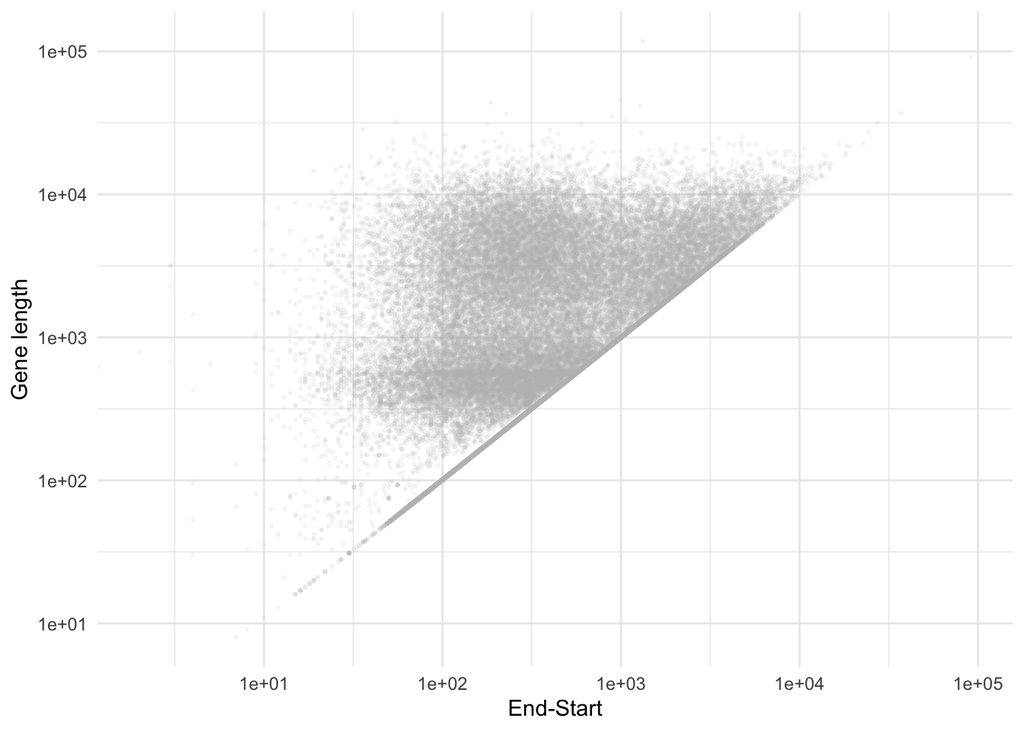

```r
plot_strend_length <-
  plot_strend_length +
    scale_x_log10("End-Start") +
    scale_y_log10("Gene length") +
    theme_minimal()

plot_strend_length
```

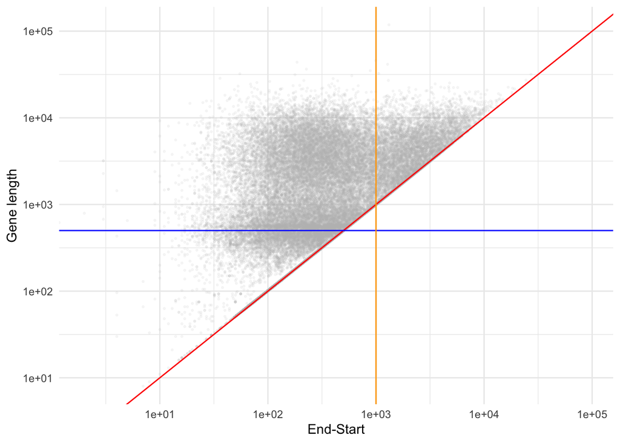

```r
plot_strend_length +
  geom_abline(intercept = 0, slope = 1, col = "red") +
  geom_hline(yintercept = 500, color = "blue") +
  geom_vline(xintercept = 1000, color = "orange")
```

```r
gene_loc %>%
  group_by(Chr) %>%
  summarize(meanLength = mean(Length), numGenes = n())
```

```
## # A tibble: 25 × 3
##    Chr   meanLength numGenes
##    <fct>      <dbl>    <int>
##  1 chr1       2258.     5363
##  2 chr2       2304.     4047
##  3 chr3       2382.     3101
##  4 chr4       2109.     2563
##  5 chr5       2188.     2859
##  6 chr6       2124.     2905
##  7 chr7       2164.     2876
##  8 chr8       2036.     2386
##  9 chr9       2123.     2323
## 10 chr10      2160.     2260
## # ℹ 15 more rows
```

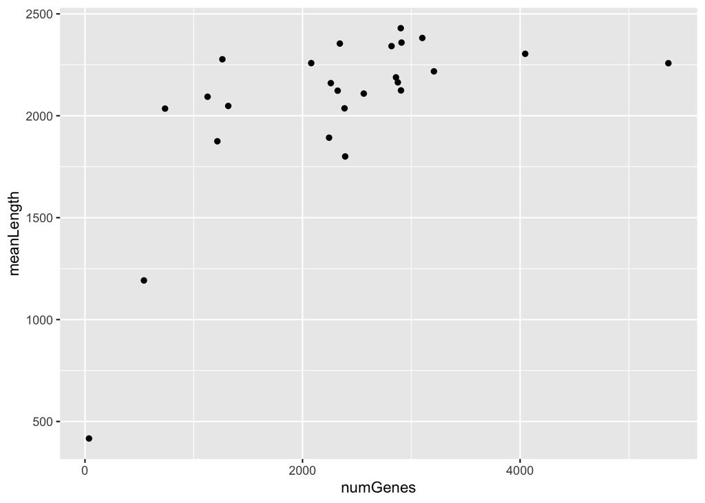

```r
gene_loc %>%
  group_by(Chr) %>%
  summarize(meanLength = mean(Length), numGenes = n()) %>%
  ggplot(aes(x = numGenes, y = meanLength)) +
   geom_point()
```

[output not shown]

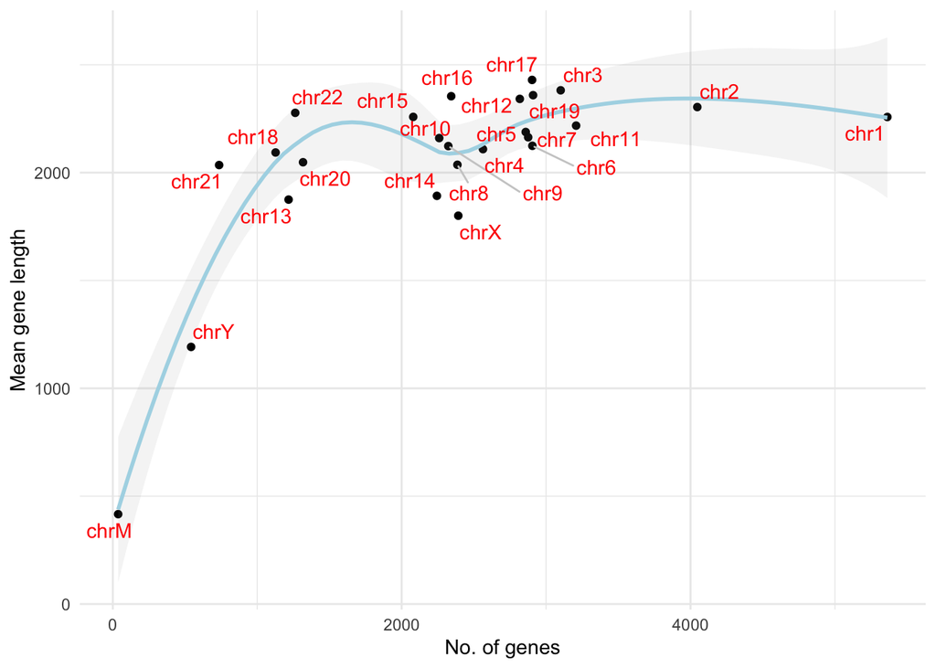

```r
# install.packages("ggrepel", dependencies=T)
library(ggrepel)
gene_loc %>%
  group_by(Chr) %>%
  summarize(meanLength = mean(Length), numGenes = n()) %>%
  ggplot(aes(x = numGenes, y = meanLength)) +
    geom_point() +
    geom_smooth(color = "lightblue", alpha = 0.1) +
    labs(x = "No. of genes", y = "Mean gene length") +
    geom_text_repel(aes(label = Chr), color="red", segment.color="grey80") +
    theme_minimal()
```

### Boxplots & Violin plots

- `geom_boxplot`, `geom_violin`
- `scale_y_continuous`

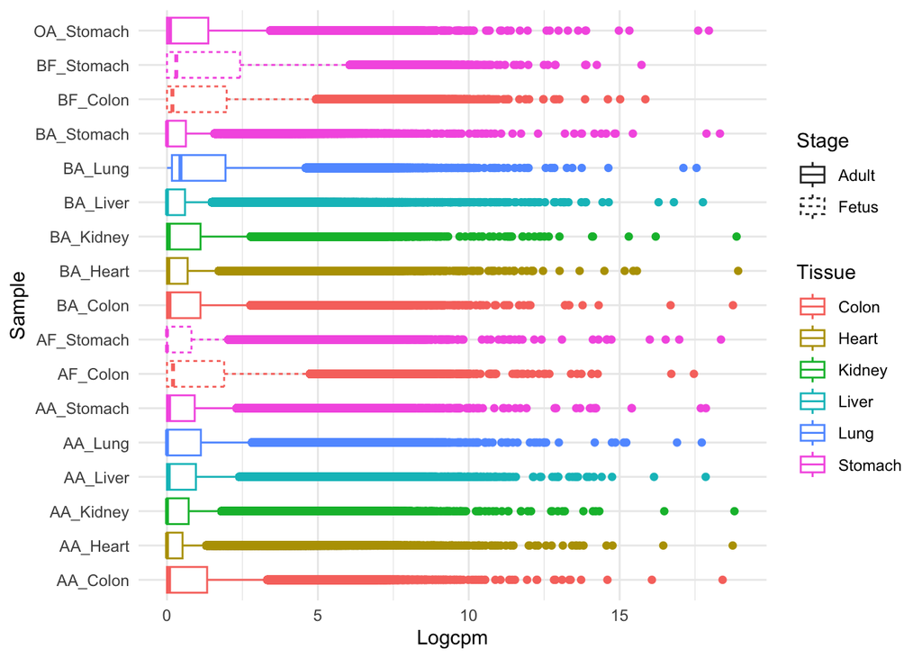

```r
log_cpm_long %>%
  ggplot(aes(x = Sample, y = Logcpm, color = Tissue, linetype = Stage)) +
    geom_boxplot() +
    coord_flip() +
    theme_minimal()
```

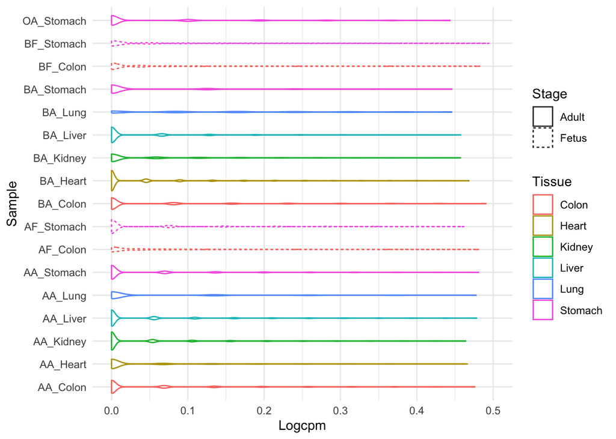

```r
log_cpm_long %>%
  ggplot(aes(x = Sample, y = Logcpm, color = Tissue, linetype = Stage)) +
    geom_violin() +
    scale_y_continuous(limits = c(0, 0.5)) +
    coord_flip() +
    theme_minimal()
```

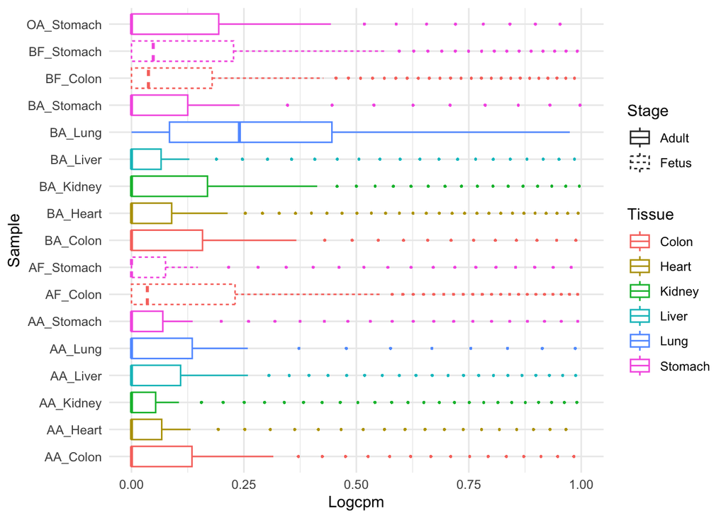

```r
# Plotting the distribution of gene-expression in each sample
plot_sample_bxp <- log_cpm_long %>%
  ggplot(aes(x = Sample, y = Logcpm, color = Tissue, linetype = Stage)) +
    geom_boxplot(outlier.size = 0.2, outlier.alpha = 0.2) +
    scale_y_continuous(limits = c(0, 1)) +
    coord_flip() +
    theme_minimal()

plot_sample_bxp
```

### Reorganize a dataframe before plotting

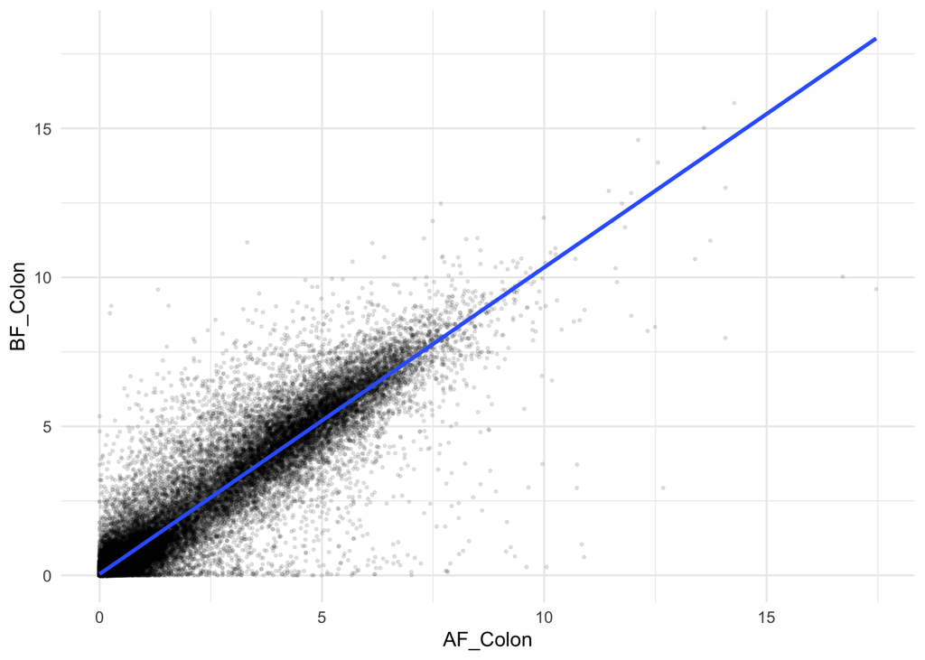

```r
# How similar is the gene expression from two different
# sequencing technologies in the same tissue?

plot_ffcolon_scatter <- log_cpm_long %>%
  filter(Sample == "AF_Colon" | Sample == "BF_Colon") %>%
  select(Geneid, Sample, Logcpm) %>%
  pivot_wider(names_from = Sample, values_from = Logcpm) %>%
  ggplot(aes(x = AF_Colon, y = BF_Colon)) +
    geom_point(alpha = 0.1, size = 0.5) +
    geom_smooth(method=lm) +
    theme_minimal()

plot_ffcolon_scatter
```

# Section 5: Export

## Saving your plots

### ggsave

**Save a ggplot (or other grid object) with sensible defaults**

```r
library(tidyverse)
# make a new folder called "part1_results" with an "if" statment
if(!dir.exists("part1_results")){dir.create("part1_results")}

# save the file name
plot1_name <- "colon_expression_comparison_scatter.png"

# save the full path to your file
project_path <- getwd()
results_path <- paste(project_path, "part1_results", sep="/")

# To save as a tab-delimited text file ...
ggsave(filename=plot1_name,
       path=results_path,
       plot=plot_ffcolon_scatter,
       device="png",
       dpi=600)
```

## Saving your data files

### write_csv & write_tsv

**Write a dataframe to a delimited file**

```r
library(tidyverse)
# Save your file name
filename <- "gse69360_tidy.txt"

# Save your absolute/relative path
data_path <- paste(getwd(), "data", sep="/")

# To save as a tab-delimited text file ...
write_tsv(log_cpm_long, # your final reformatted dataset
          file=paste(data_path, filename, sep = "/"), # Absolute path recommended.
          # However, you can directly use 'filename' here
          # if you are saving the file in the same directory
          # as your code.
          col_names=T) # if you want the column names to be
# saved in the first row, recommended

# Alternatively, you could save it as a comma-separated text file
write_csv(x=log_cpm_long,
          file=paste(data_path, filename, sep = "/"),
          col_names=T)
```